# Stat 579 - Homework #5

Urminder Singh

9/27/2018

## Flying etiquette

FiveThirtyEight is a website founded by Statistician and writer Nate Silver to publish results from opinion poll analysis, politics, economics, and sports blogging. One of the featured articles considers [flying etiquette](https://fivethirtyeight.com/features/airplane-etiquette-recline-seat/). This article is based on data collected by FiveThirtyEight and publicly available on github. Use the code below to read in the data from the survey:

```r
fly <- read.csv("flying-etiquette.csv")
library(ggplot2)
library(plyr)
```

The following couple of lines of code provide a bit of cleanup of the demographic information by reaordering the levels of the corresponding factor variables. Run this code in your session.

```r
fly$Age <- factor(fly$Age, levels=c("18-29", "30-44", "45-60", "> 60", ""))
fly$Household.Income <- factor(fly$Household.Income, levels = c("$0 - $24,999","$25,000 - $49,999", "$50,000 - $99,999", "$100,000 - $149,999", "150000", ""))
fly$Education <- factor(fly$Education, levels = c("Less than high school degree", "High school degree", "Some college or Associate degree", "Bachelor degree",  "Graduate degree", ""))
```

1. Download the RMarkdown file with these homework instructions to use as a template for your work. Make sure to replace “Your Name” in the YAML with your name.
2. Some people do not travel often by plane. Provide a (visual) breakdown of travel frequency (use variable `How.often.do.you.travel.by.plane.`). Reorder the levels in the variable by travel frequency from least frequent travel to most frequent. Draw a barchart of travel frequency and comment on it. Exclude all respondents who never fly from the remainder of the analysis. How many records does the data set have now?

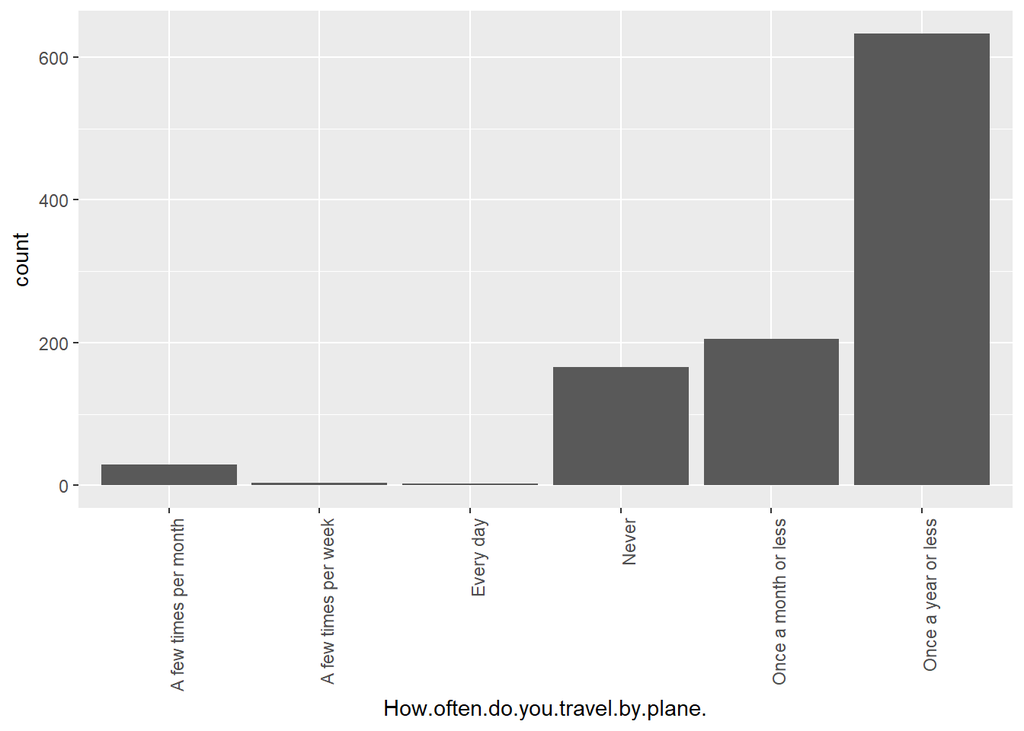

```r
ggplot(data=fly, aes(x=How.often.do.you.travel.by.plane.)) +  geom_bar(stat = "count")+ theme(axis.text.x = element_text(angle = 90, hjust = 1))
```

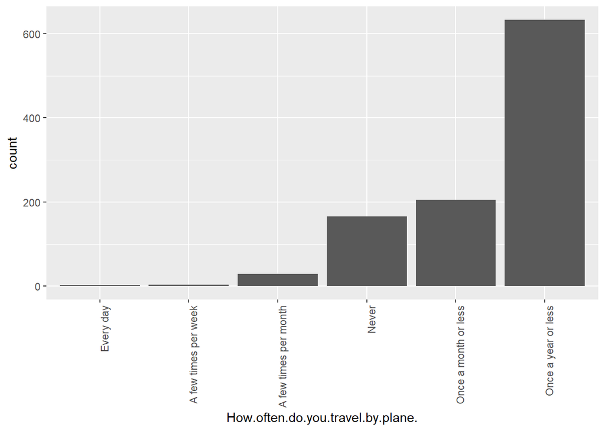

```r
#reorder data
#get counts for each level
counts<-count(fly$How.often.do.you.travel.by.plane.)
fly$How.often.do.you.travel.by.plane. <- factor(fly$How.often.do.you.travel.by.plane., levels = counts[order(counts$freq),1])
#plot increasing order
ggplot(data=fly, aes(x=How.often.do.you.travel.by.plane.)) +  geom_bar(stat = "count")+ theme(axis.text.x = element_text(angle = 90, hjust = 1))
```

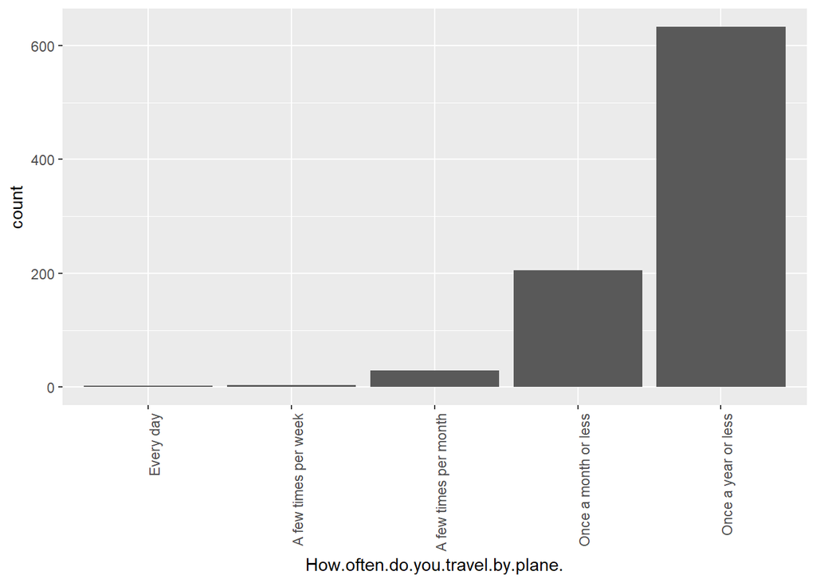

```r
fly2<-fly[which(!fly$How.often.do.you.travel.by.plane.=="Never"),]
ggplot(data=fly2, aes(x=How.often.do.you.travel.by.plane.)) +  geom_bar(stat = "count")+ theme(axis.text.x = element_text(angle = 90, hjust = 1))
```

```r
dim(fly2)
```

```
## [1] 874  27
```

After reordering the plot we see that most people fly once a year or less. The count decreases with increase in frequence of travel.

After excluding people who never fly we have 874 rows left in the data.

3. In the demographic variables (`Education`, `Age`, and `Houshold.Income`), replace all occurrences of the empty string “” by a missing value `NA`. How many responses in each variable do not have any missing values? How many responses have no missing values in any of the three variables? (Hint: think of the function `is.na`)

```r
#Replace "" with NA
fly2$Education[which(fly2$Education=="")]=NA
fly2$Age[which(fly2$Age=="")]=NA
fly2$Household.Income[which(fly2$Household.Income=="")]=NA
#how many ecucation are not NA
length(which(!is.na(fly2$Education)))
```

```
## [1] 837
```

```r
length(which(!is.na(fly2$Age)))
```

```
## [1] 843
```

```r
length(which(!is.na(fly2$Household.Income)))
```

```
## [1] 698
```

```r
#no missing in Education or Age or Houshold.Income
length(which(!is.na(fly2$Education) | !is.na(fly2$Age) | !is.na(fly2$Household.Income)))
```

```
## [1] 843
```

```r
length(which (!(is.na(fly2$Education) & is.na(fly2$Age) & is.na(fly2$Household.Income))))
```

```
## [1] 843
```

Education has 837 non-missing values

Age has 843 non-missing values

Household.Income has 698 non-missing values

843 rows has non-missing values in Education or Age or Houshold.Income variables

4. Run the command below and interpret the output. What potential purpose can you see for the chart? What might be a problem with the chart? Find at least one purpose and one problem.

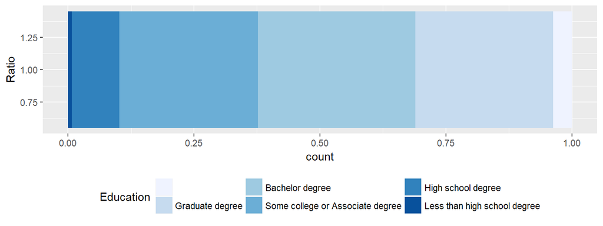

```r
fly$Education = with(fly, factor(Education, levels = rev(levels(Education))))

ggplot(data = fly, aes(x = 1)) +
  geom_bar(aes(fill=Education), position="fill") +
  coord_flip() +
  theme(legend.position="bottom") +
  scale_fill_brewer() +
  xlab("Ratio")
```

The plot shows the proportions of responses for each educational level. The advantage is that this plot is simple and easy to interpret. This plot can easily convey the message about the educational qualifications of the respondents and what were their proportions. One disadvantage is that it only shows relative propotion and comparing closely matched proportions is hard. For example proportion of Graduate degree bachelor degree and some college degree all looks same. It is hard to tell which is largest and lowest. On the other hand it is pretty easy to see that high school degree is much less than graduate degree. Another disadvantage is that x-axis is usesless for this particular case and can be confusing.

5. Rename the variable `In.general..is.itrude.to.bring.a.baby.on.a.plane.` to `baby.on.plane.`. How many levels does the variable `baby.on.plane` have, and what are these levels? Rename the level labeled “” to “Not answered”. Bring the levels of `baby.on.plane` in an order from least rude to most rude. Put the level “Not answered” last. Draw a barchart of variable `baby.on.plane`. Interpret the result. (This question is very similar to question 2, but preps the data for the next question)

```r
c<-which(colnames(fly2)=="In.general..is.itrude.to.bring.a.baby.on.a.plane.")
colnames(fly2)[19]="baby.on.plane."
length(levels(fly2$baby.on.plane.))
```

```
## [1] 4
```

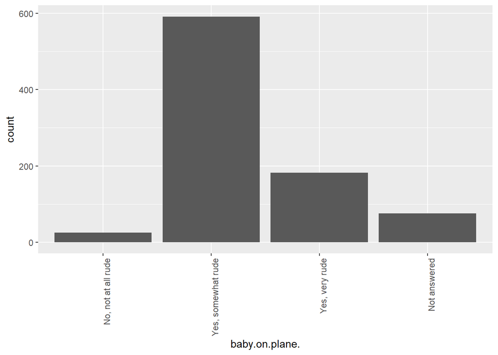

```r
#change levels
levels(fly2$baby.on.plane.)[1] <- "Not answered"
levels(fly2$baby.on.plane.)<-levels(factor(fly2$baby.on.plane., levels=c("No, not at all rude", "Yes, somewhat rude","Yes, very rude","Not answered")))
#plot increasing order
ggplot(data=fly2, aes(x=baby.on.plane.)) +  geom_bar(stat = "count")+ theme(axis.text.x = element_text(angle = 90, hjust = 1))
```

baby.on.plane has 4 levels “”, “No, not at all rude”, “Yes, somewhat rude”, and “Yes, very rude”

From the plot we can say that majority of people think it is somewhat rude to bring a baby on plane. People who think it is very rude are greater that those who think its not rude at all. Many people aslo didn’t answer so we have missing values.

6. Investigate the relationship between gender and the variables `Do.you.have.any.children.under.18.` and `baby.on.plane`. How is the attitude towards babies on planes shaped by gender and own children under 18? Find a plot that summarises your findings (use `ggplot2`).

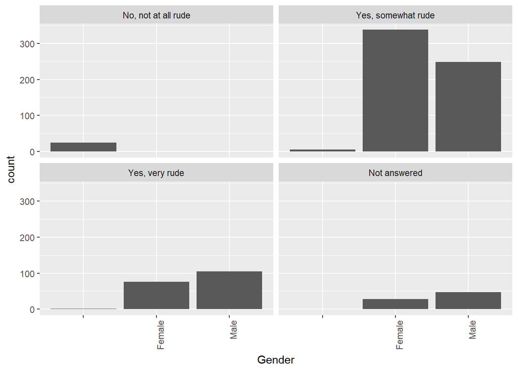

```r
ggplot(data=fly2, aes(x=Gender)) +  geom_bar(stat = "count")+facet_wrap(~baby.on.plane.)+ theme(axis.text.x = element_text(angle = 90, hjust = 1))
```

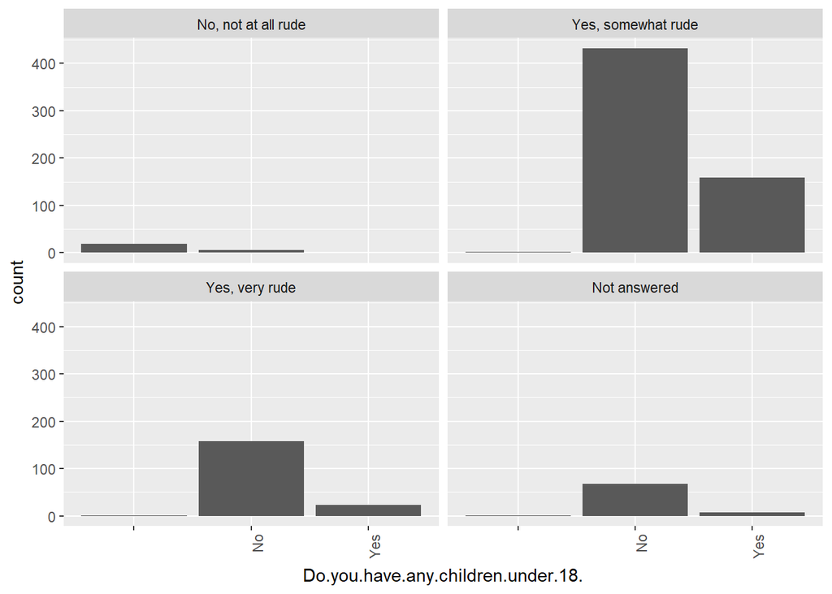

```r
ggplot(data=fly2, aes(x=Do.you.have.any.children.under.18.)) +  geom_bar(stat = "count")+facet_wrap(~baby.on.plane.)+ theme(axis.text.x = element_text(angle = 90, hjust = 1))
```

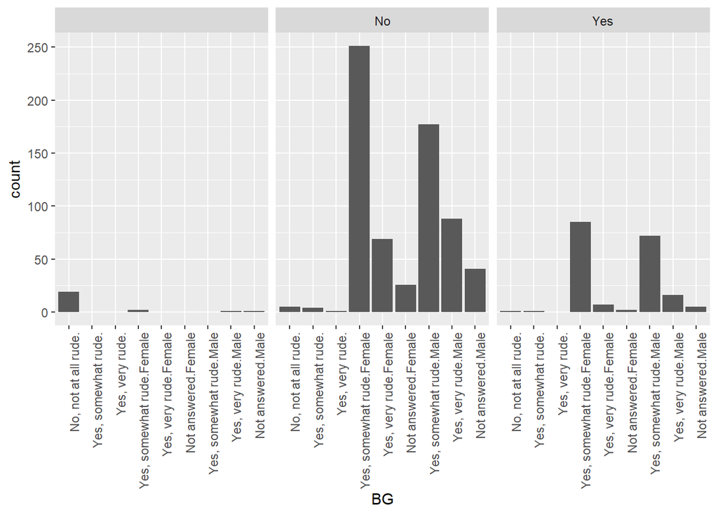

```r
fly2$BG <- interaction(fly2$baby.on.plane., fly2$Gender)

ggplot(aes(x = BG), data = fly2) + geom_bar(stat = "count")+facet_wrap(~Do.you.have.any.children.under.18.)+ theme(axis.text.x = element_text(angle = 90, hjust = 1))
```

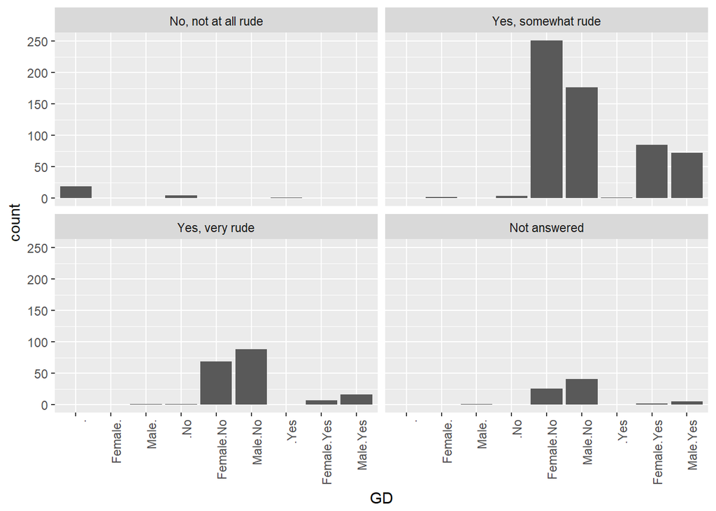

```r
fly2$GD <- interaction( fly2$Gender,fly2$Do.you.have.any.children.under.18.)

ggplot(aes(x = GD), data = fly2) + geom_bar(stat = "count")+facet_wrap(~baby.on.plane.)+ theme(axis.text.x = element_text(angle = 90, hjust = 1))
```

I plotted a few charts to investigate how the variables gender, `Do.you.have.any.children.under.18.` and `baby.on.plane` are related. From the graphs I can conclude the following:

- Higher number of Male gender cansiders baby on plane to be very rude as compared to female. This trend is opposite for the somewhat rude category.
- People who think its not rude at all did not reveal their gender.
- More people without children under 18 responded very rude as compared to people with children under 18. This trend is similar with people who responded somewhat rude and not answered
- Finally we can say that both male and female without children responded very rude and somewhat rude as compared to male and female with children. Most people think it is somewhat rude with females with no children highest in that category. MOst people with no answer were male and females with no children under 18.